# Zielony wzrost: przyszłość czy utopia?

Tomasz Przechlewski

czerwiec/2024

# Problem

W Porozumieniu paryskim (2015) postawiono za cel utrzymanie wzrostu średniej temperatury na świecie znacznie poniżej 2°C, a docelowo do 1,5°C względem epoki przedprzemysłowej.

**Globalny budżet węglowy** (global carbon budget), to ilość CO², która wyemitowana do atmosfery nie podwyższy temperatury wyżej niż owe magiczne 1,5/2,0°C.

GBW da się określić z pewnym prawdopodobieństwem. Im wyższa pewność tym niższa ilość CO², którą można przepalić (https://ourworldindata.org/how-much-co2-can-the-world-emit-while-keeping-warming-below-15c-and-2c)

[figure not shown]

# Wzrost

Wzrost gospodarczy to proces, w którym następuje zwiększenie produkcji dóbr i usług.

Suma wartości wszystkich dóbr i usług finalnych wytworzonych w danym kraju to dochód narodowy vel produkt krajowy (PKB).

https://en.wikipedia.org/wiki/Green_growth

Wg Banku Światowego bogactwo (**high income countries**) zaczyna się od poziomu 13,846 USD/głowę (za rok 2022). Takich krajów jest 70. Ich udział w globalnym GDP wynosi 60%, a liczba ludności stanowi 15% ludności świata.

OK, lada dzień będzie znacząco równiej ponieważ Chiny ze średnim tempem wzrostu GDP w latach 2010–2022 wynoszącym 651.5 USD/pc/rok powinny osiągnąć 14150 USD w roku 2024 a 14800 USD w roku 2025…

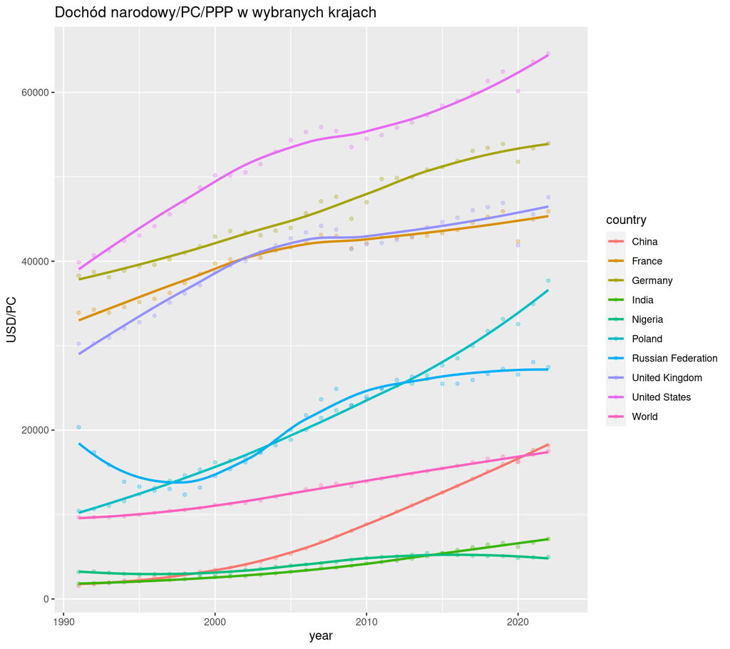

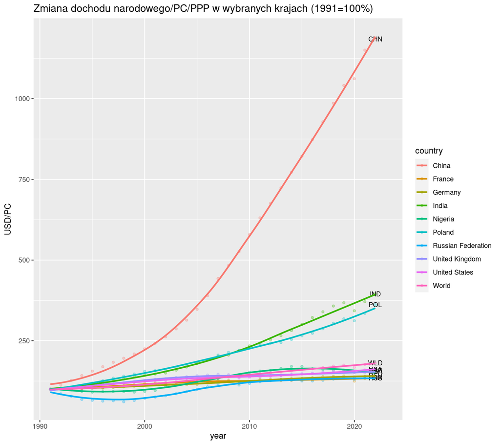

| iso3 | śr roczny | lata* | wzrost | śr roczny | lata* | wzrost |
| --- | --- | --- | --- | --- | --- | --- |
| CHN | 8.333728 | 32 | 1085.10319 | 6.1689601 | 13 | 104.712262 |
| DEU | 1.135701 | 32 | 40.93437 | 1.1821858 | 13 | 14.830847 |
| FRA | 1.008162 | 32 | 35.41830 | 0.7608471 | 13 | 8.918421 |
| GBR | 1.524029 | 32 | 57.43771 | 1.1344749 | 13 | 13.265500 |
| IND | 4.568654 | 32 | 295.11091 | 4.5279148 | 13 | 68.797215 |
| NGA | 1.499416 | 32 | 55.65765 | 0.2108039 | 13 | 2.180116 |
| POL | 4.253494 | 32 | 261.43559 | 3.9820456 | 13 | 59.147219 |
| RUS | 1.169361 | 32 | 34.95708 | 1.1728956 | 13 | 14.561981 |
| USA | 1.585950 | 32 | 62.07913 | 1.4479024 | 13 | 18.551777 |
| WLD | 1.947588 | 32 | 81.02761 | 1.9714857 | 13 | 26.099478 |

- 1991–2022; ** 2010–2022

# Emisja CO2 (ogólnie gazów cieplarnianych)

Rocznie szacowana na 40–50mld ton

Może być liczona jako wielkość produkcji lub konsumpcji (production- vs consumption-based)

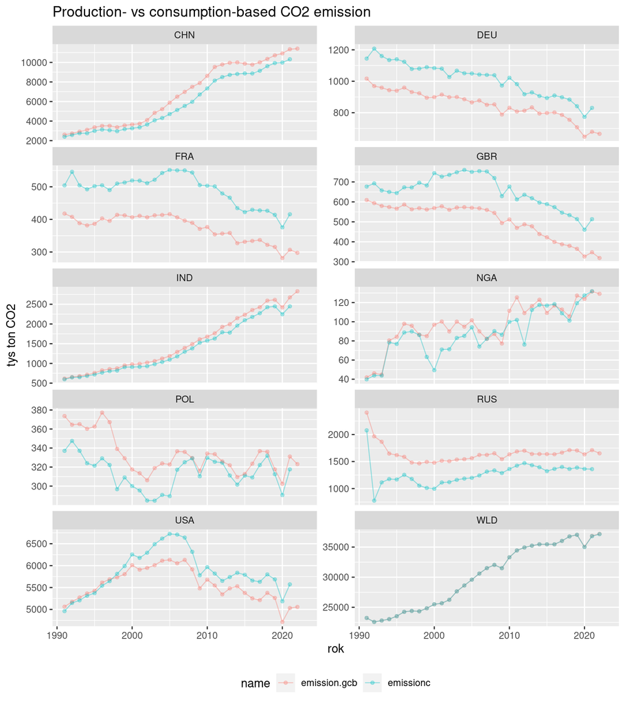

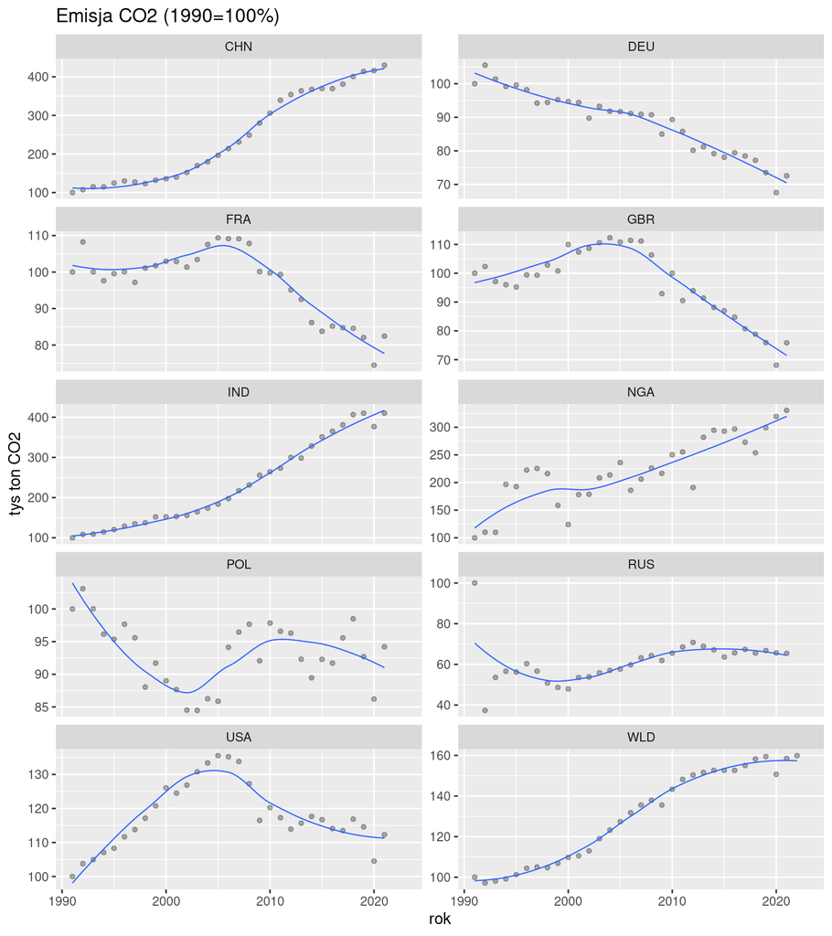

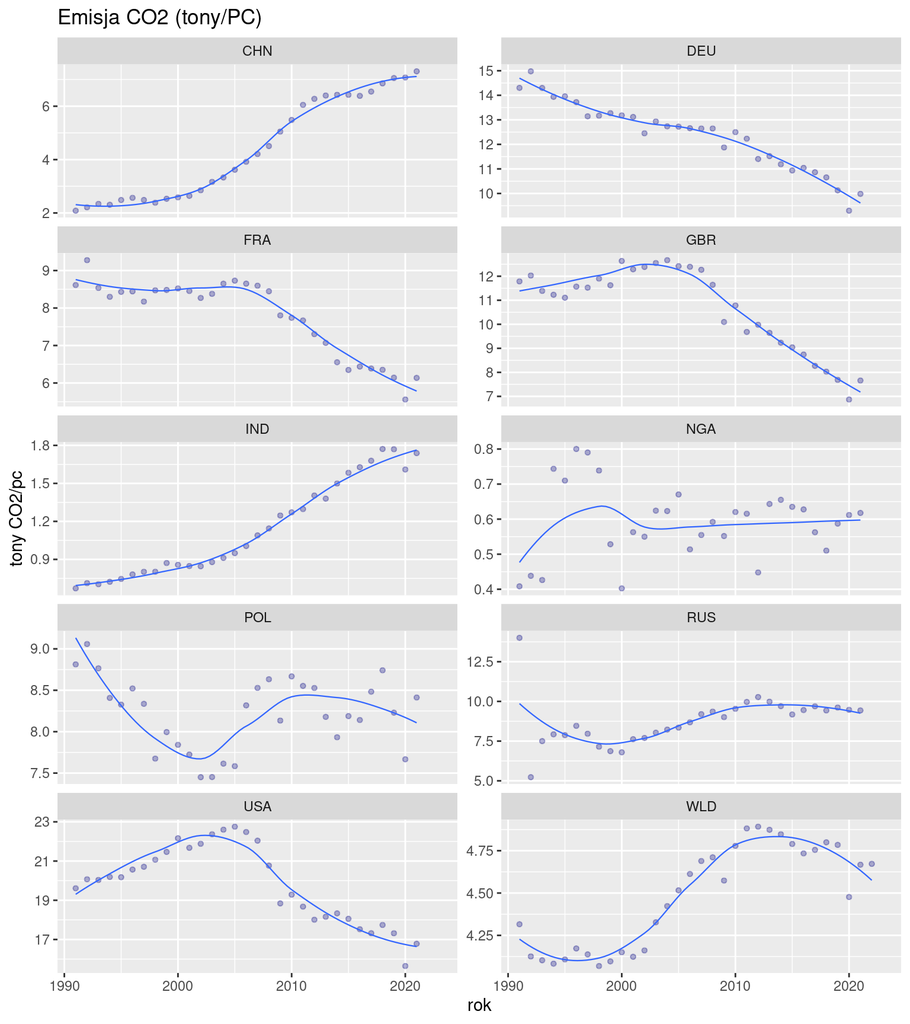

# Emisja PC a emisja łącznie

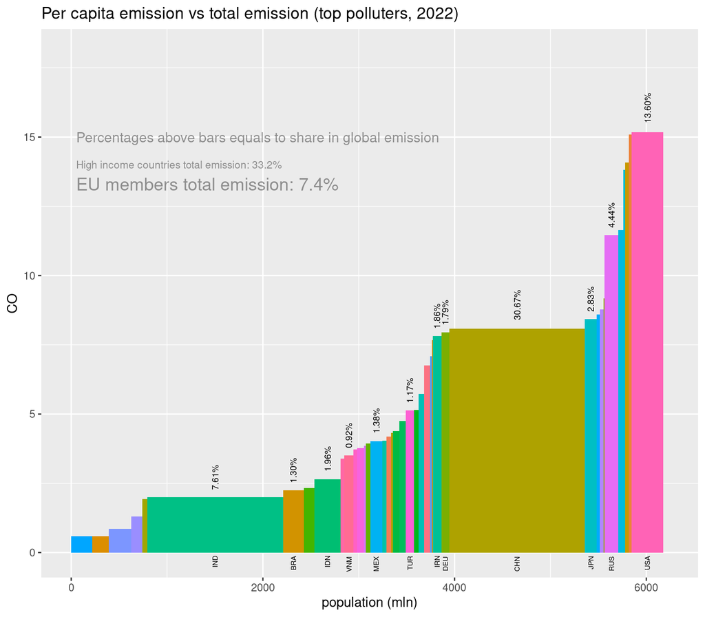

# Ślad materiałowy

Sustainable development depends on **decoupling** economic growth from resource use

Environment action programme […] calls for a significant decrease in the EU’s **material footprint** to safeguard precious natural resources and because the extraction and processing of these resources has significant environmental impacts, such as **climate change**

in […] Resource-Efficient Europe the main indicator used is GDP divided by Domestic Material Consumption (DMC).

- decoupling,
- dematerialization,
- circular economy

# Domestic material consumption vs Material footprint

**Krajowa konsumpcja materialna** (DMC) mierzy całkowitą ilość materiałów faktycznie zużytych przez daną gospodarkę,

**Ślad materiałowy** (MF): potencjalnej ilości materiałów, wymaganej do końcowego zaspokojenia potrzeb tej gospodarki. Ślad materiałowy obejmuje zatem cały łańcuch produkcji i dostaw i uwzględnia również te materiały, które zostały zużyte do wytworzenia i transportu dóbr zaimportowanych.

Jeśli krajowa konsumpcja materialna jest większa niż ślad materiałowy, to znaczy, że materiały pozyskiwane przez daną gospodarkę są również eksportowane na potrzeby konsumpcji w innych krajach.

Jeśli zaś jest ona mniejsza od śladu materiałowego, oznacza to, że materiały są importowane przez gospodarkę krajową i konsumpcja w obrębie tej gospodarki wymaga pozyskania surowców z innych gospodarek.

*Polska na drodze zrównoważonego rozwoju* https://raportsdg.stat.gov.pl/2022/Raport_pdf/Raport_SDG_2022.pdf

# DMC/MF w wybranych krajach

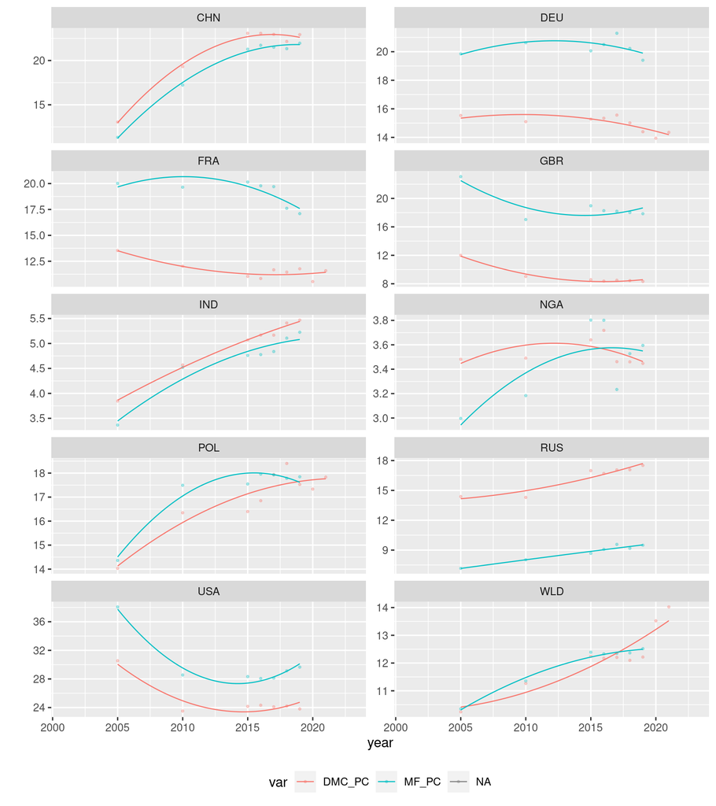

Źródło: https://stats.oecd.org/Index.aspx?DataSetCode=MATERIAL_RESOURCES

# ΔGDP vs ΔDMC w wybranych krajach

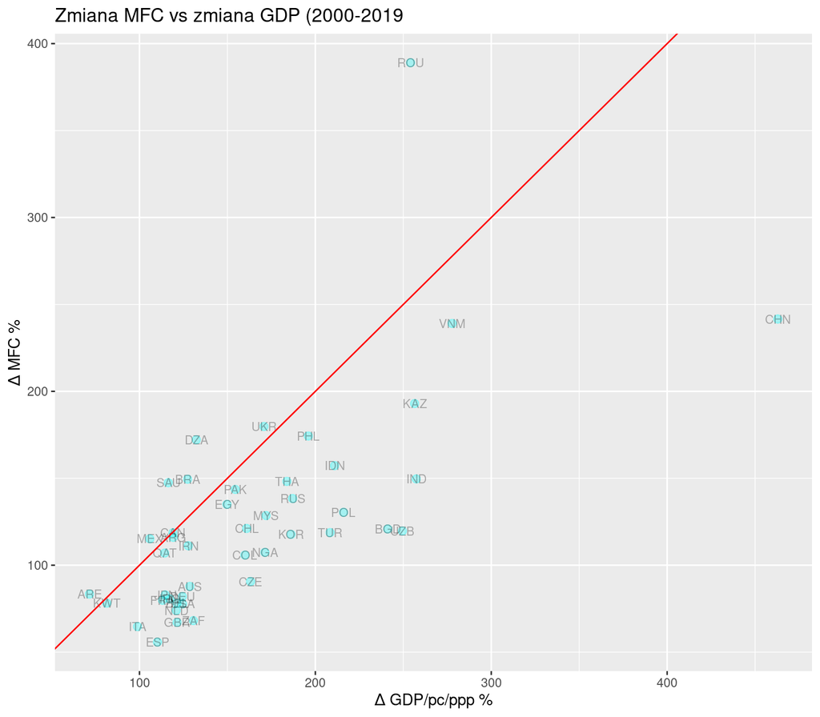

Źródło: https://stats.oecd.org/Index.aspx?DataSetCode=MATERIAL_RESOURCES

# Cement

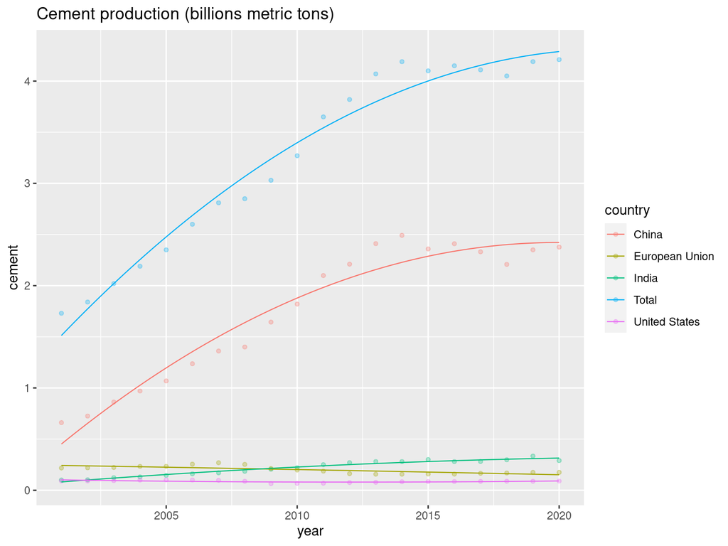

Źródło: USGS https://www.usgs.gov/centers/national-minerals-information-center/cement-statistics-and-information

# Stal (raw steel)

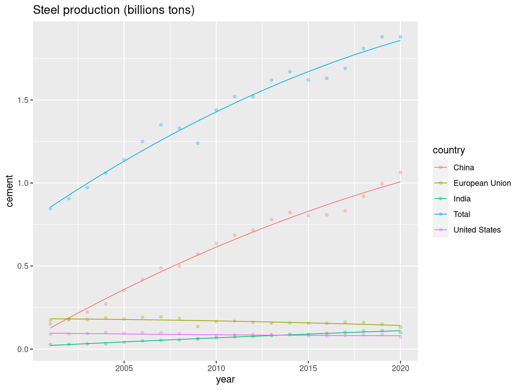

Źródło: USGS https://www.usgs.gov/centers/national-minerals-information-center/iron-and-steel-statistics-and-information

# Czas najlepszy lekarz (hipoteza EKC)

Krzywa Kuznetsa opisuje (domniemaną) zależność między rozwojem gospodarczym a nierównościami dochodowymi. https://pl.wikipedia.org/wiki/Krzywa_Kuznetsa

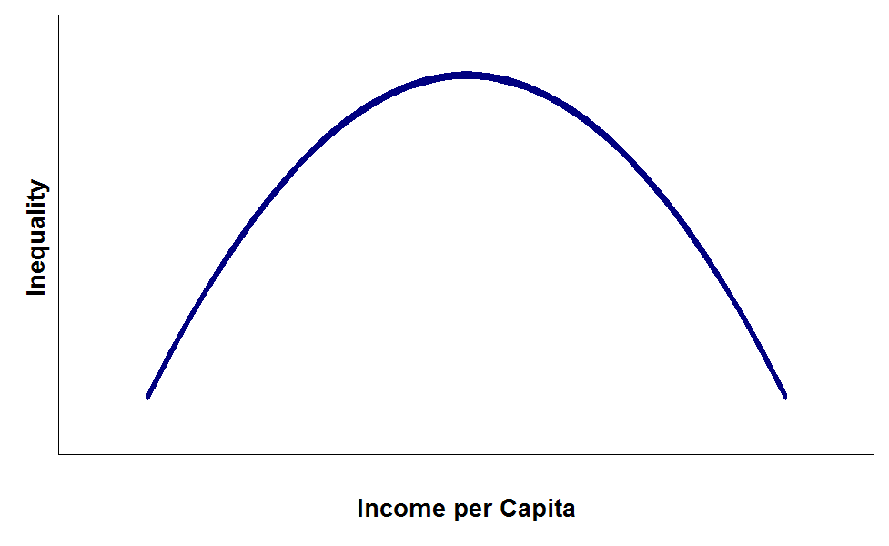

Ekologiczna krzywej Kuznetsa opisuje zależność między rozwojem gospodarczym a degradacją środowiska. Wzrost bogactwa skutkuje degradacją środowiska. Po osiągnięciu pewnego poziomu zamożności, tendencja ta się odwraca i dalszy wzrost gospodarczy prowadzi do poprawy jakości środowiska.

W początkowym okresie rozwoju działa **efekt skali**. Produkcja powiększa się a co za tym idzie rośnie zużycie surowców i zanieczyszczenie. W drugim okresie przeważa **efekt kompozycji**, w szczególności zwiększa się rola sektora usług (**dematerialization through services**)

Efekt technologiczny? Inaczej postęp (zawsze był :-)

Regulacje i instytucje (wyższy poziom dochodu pozwala na większe inwestycje w ochronę środowiska i technologie ekologiczne.)

$$\begin{align}
E &= a_0 + a_1 \cdot GDP + a_2 \cdot GDP^2\\
GDP_{\max} &= \frac{a_1}{-2 \cdot a_2}\\
E_\max &= a_0 + a_1 \cdot GDP_{\max} + a_2 \cdot GDP_{\max}^2
\end{align}$$

Model jest rozszerzany o różnego rodzaju dodatkowe (liczba ludności, wskaźnik urbanizacji, świadomość ekologiczna i inne bardziej egzotyczne) zmienne, ale rezultat jest hmmm… średni

google:EKC+Kuznets (228 tys pozycji); literalnie tysiące artykułów (serio :-)

# EKC próba oszacowania

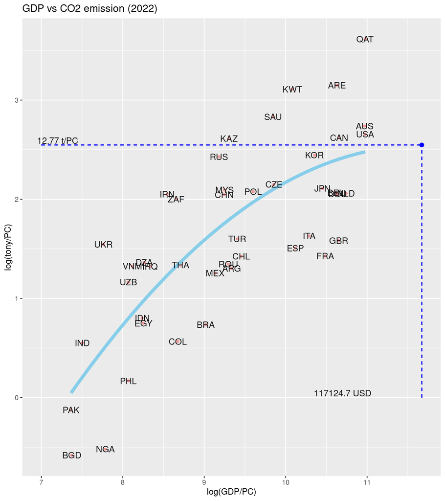

44 kraje, których emisja stanowi łącznie 90% emisji światowej.

# IPAT/STIRPAT

IPAT to jeszcze prostszy model niż EKC (*yes we can*)

Wpływ działalności człowieka na środowisko jest definiowany jako:

$$I = P\cdot A \cdot T$$

Impact (**wpływ**), population (**populacja**), affluence (**zamożność**) oraz technology (technologia).

Zużycie paliwa = populacja $\cdot$ liczba samochodów/PC $\cdot$ średnie zużycie paliwa przez samochód (jak obliczyć?)

# STIRPAT

Rozwinięcie IPAT:

$$I=aP^b A^c T^d$$
$b$, $c$, $d$ – Współczynniki elastyczności dla zmiennych $P$, $A$ i $T$

$\textrm{CO2} = a \cdot \textrm{Ludność}^b \cdot \textrm{PKB/PC}^c \cdot \textrm{Intensywność energetyczna}^d$

gdzie: Intensywność energetyczna ($T$) to ilość energii na jednostkę PKB, odzwierciedlające efektywność technologii.

Dla 44 krajów (emisja CO2 stanowi łącznie 90% emisji światowej) oszacowano model STIRPAT (`EG.EGY.PRIM.PP.KD`):

$\textrm{CO2} = -24,4 \cdot \textrm{Ludność}^{1,01} \cdot \textrm{PKB/PC}^{1,09} \cdot \textrm{Intensywność energetyczna}^{0,75}$

**Można też inaczej**

- Średni roczny wzrost PKB w latach 1991–2022 (jak ustaliliśmy wynosił) około 1,9%;
- Liczba ludności (2022): 7950946801 i według **UN World Population Prospects 2022 revision** wzrośnie do 9,7 mld.
- Załóżmy, że wzrost w ciągu 28 lat do 2050 roku obniży się do 1,5%/rocznie. PKB/pc wzrośnie zatem o 51% a liczba ludności o 22.0%.
- Łącznie daje to 84.2%.

Czynnik $T$ powinien się obniżać o około 2% rok/rok żeby w ogóle nadążyć za zamianami $PKB$/$P$

https://population.un.org/dataportal/data/indicators/49/locations/900/start/1950/end/2100/line/linetimeplotsingle?df=a3987625-5dda-4d6e-9455-89299db5ca71

# Dwa scenariusze

- Czynnik $T$ obniża się o 2%. Czynnik $T$ obniża się o 5%.
- W pierwszym wariancie zostaje do 2050 roku wyprodukowane około 1,000 mld/Co2; w drugim 700mld. [Przy czym GCB liczy tylko **emissions from fossil fuels and industry**; emisja całkowita może być do 30% wyższa 1300/910]
- Dla przypomnienia zginiemy jeżeli zostanie wyemitowane dodatkowe 950 Mld/ton/Co2

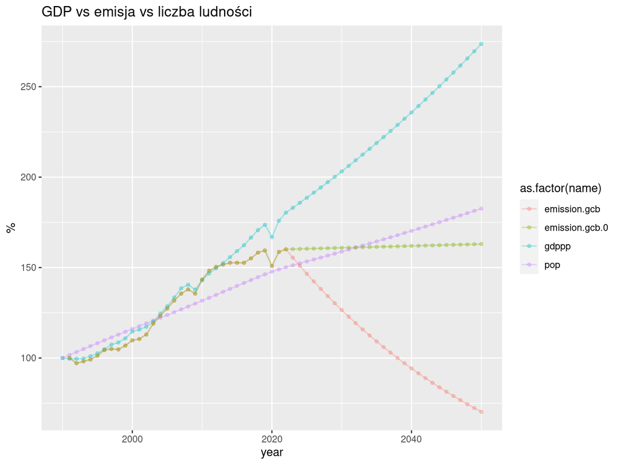

# Propozycja realistyczno-pozytywna: degrowth

https://pl.wikipedia.org/wiki/Degrowth

Degrowth: A response to Branko Milanovic https://www.jasonhickel.org/blog/tag/degrowth

counting GDP is irrelevant

World average GDP […] is poorly distributed and poorly utilized [World Bank’s threshold for “high-income is?]

We could achieve all of our social goals, for every person in the world, with much less GDP than we presently have

capitalism is highly inefficient when it comes to meeting human needs

It’s not income itself that counts

Degrowth does not seek to scale down all sectors; just unnecessary and destructive ones

# Wnioski

Przyszłość czy utopia? [From the scientific point of view]

# Zakończenie i dane

- Bank Światowy + Global Carbon Project (2023)
- OECD
- USGS